# statistics

*04_inferential_statistics/03_hypothesis_tests_one_sample/03_hyptest_single_mean_raw_archery_v4*

Archie worries the horizontal aspect of her sight may be off. She decides to run a [one-sample t test](https://en.wikipedia.org/wiki/Student's_t-test#Uses) on the $x$ values of her next 24 arrows. She will use a [significance level](https://en.wikipedia.org/wiki/Statistical_significance) of $\alpha=0.05$. If the result has statistical significance, Archie will adjust her sight.

### Result

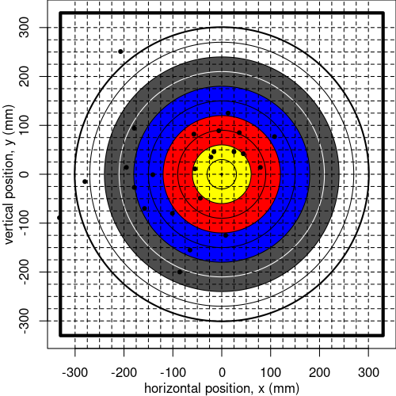

The horizontal positions are shown below and can be downloaded as a csv.

```
-86, -195, -6, 13, -65, -22, -179, -332, -280, 25, -207, -179, -55, -16, 108, -101, -141, 44, 8, -158, -44, 79, -57, 36
```

### Analysis

To get the $p$-value:
$$p\text{-value} ~=~ P\left(\big|T\big| > \frac{\big|\bar{x}-\mu_0\big|}{s/\sqrt{n}} \right)$$

In this situation, the null population mean is zero.
$$\mu_0=0$$
In other words, [the null hypothesis](https://en.wikipedia.org/wiki/Exclusion_of_the_null_hypothesis) claims the sight is correct and the difference between $\bar{x}$ and 0 is just due to chance. The [alternative hypothesis](https://en.wikipedia.org/wiki/Alternative_hypothesis) claims the sight needs to be adjusted: the difference between $\bar{x}$ and 0 is partly because the sight is off.

Determine the $p$-value.

Archie will adjust her sight if the $p$-value is less than 0.05, because this indicates there is statistical significance. Does Archie adjust her sight?

Yes. / No.